# Cumulative Logit Models for Multi-Ordinal Responses

November 08, 2017

\[ \newcommand{\Prob}{\operatorname{P}} \newcommand{\E}{\operatorname{E}} \newcommand{\Var}{\operatorname{Var}} \newcommand{\Cov}{\operatorname{Cov}} \newcommand{\se}{\operatorname{se}} \newcommand{\re}{\operatorname{re}} \newcommand{\ybar}{{\overline{Y}}} \newcommand{\phat}{{\hat{p}}} \newcommand{\that}{{\hat{T}}} \newcommand{\med}{{\tilde{Y}}} \newcommand{\Logit}{{\operatorname{Logit}}} \]

## Theory

## Data

- \(Y_{i}\) is Ordinal \[ Y_{i} = 1, 2, \dots, J \]
- Ex: Likert Scale \[ Y_{i} = \begin{cases} 1,\text{ if Strongly Disagree} \\ 2,\text{ if Disagree} \\ 3,\text{ if Neither Agree or Disagree} \\ 4,\text{ if Agree} \\ 5,\text{ if Strongly Agree} \end{cases} \]

## Cumulative Logit

- Recall: \[ \Prob\left( Y \leq j \right) = \sum_{i=1}^{j}\pi_{i} \]
- Let: \[ L_{j} = \Logit\left[ \Prob\left( Y \leq j \right) \right] = \ln\left[ \frac{\Prob\left( Y \leq j \right)}{1 - \Prob\left( Y \leq j \right)} \right] = \ln\left[ \frac{\sum_{i=1}^{j}\pi_{i}}{\sum_{i=j+1}^{J}\pi_{i}} \right] \]
- Where: \[ j = 1, 2, \dots J-1 \]

## Cumulative Logit Model

- We can consider \(J-1\) logistic regressions, each measuring the log odds of \(Y_{i} \leq j\) vs. \(Y_{i} > j\) \[ L_{j} = \beta_{j,0} + \sum_{i=1}^{p}\beta_{j,i}X_{i} \]
- Ex: \[ L_{1} = \beta_{1,0} + \sum_{i=1}^{p}\beta_{1,i}X_{i} \] \[ L_{2} = \beta_{2,0} + \sum_{i=1}^{p}\beta_{2,i}X_{i} \] \[ \vdots \] \[ L_{J-1} = \beta_{J-1,0} + \sum_{i=1}^{p}\beta_{J-1,i}X_{i} \]

## Proportional-Odds

- However because all the \(\beta_{j,i}\)'s differ, we can't make a comparison to the baseline model! \[ L_{j} = \alpha_{j} - \left( \sum_{i=1}^{p}\beta_{i}X_{i} \right), \forall j = 1,2,\dots, J-1 \]
- Hold the \(\beta_{i}\)'s constant and only vary \(\alpha_{j}\)
- Note: \[ L_{1} \leq L_{2} \leq \dots \leq L_{J-1} \]

## Probability

- Rearranging: \[ \Prob\left( Y \leq j \middle| X_{i} = x_{i}, \forall i = 1, \dots, p \right) = \frac{e^{\alpha_{j} - \left( \sum_{i=1}^{p}\beta_{i}X_{i}\right)}}{1 + e^{\alpha_{j} - \left( \sum_{i=1}^{p}\beta_{i}X_{i}\right)}} \] \[ \implies \Prob\left( Y = j \right) = \Prob\left( Y \leq j \right) - \Prob\left( Y \leq j-1 \right) = \Prob\left( Y > j-1 \right) - \Prob\left( Y > j \right) \] \[ = \frac{1}{1 + e^{\alpha_{j} - \left( \sum_{i=1}^{p}\beta_{i}X_{i}\right)}} - \frac{1}{1 + e^{\alpha_{j} - \left( \sum_{i=1}^{p}\beta_{i}X_{i}\right)}} \]

## Example

## Ideology by Gender and Political Party

| Party | Ideology | Gender |
| --- | --- | --- |
| Democrat | VL | F |
| Democrat | VL | F |
| Democrat | VL | F |
| Democrat | VL | F |
| Democrat | VL | F |
| Democrat | VL | F |

\[ VL < SL < M < SC < VC \] \[ \implies J = 5 \]

## Regression

```
##
## Re-fitting to get Hessian
```

```
## Call:
## MASS::polr(formula = Ideology ~ Party, data = pol_tidy)
##
## Coefficients:
##                  Value Std. Error t value
## PartyRepublican 0.9745     0.1292   7.544
##
## Intercepts:
##       Value    Std. Error t value
## VL|SL  -1.4944   0.1136   -13.1558
## SL|M   -0.5000   0.0945    -5.2929
## M|SC    1.2116   0.1038    11.6770
## SC|VC   2.0441   0.1193    17.1288
##
## Residual Deviance: 2474.985
## AIC: 2484.985
```

## Coefficients

\[ \alpha_{1} = -1.4944 \] \[ \alpha_{2} = -0.5000 \] \[ \alpha_{3} = 1.2116 \] \[ \alpha_{4} = 2.0441 \] \[ \beta = 0.9745 \] \[ X = \begin{cases} 0,\text{ if Democrat} \\ 1,\text{ if Republican} \end{cases} \] - For a fixed \(j\), the estimated log odds in favour of being more conservative than more liberal is 0.9745 greater for a Republican vs. a Democrat.

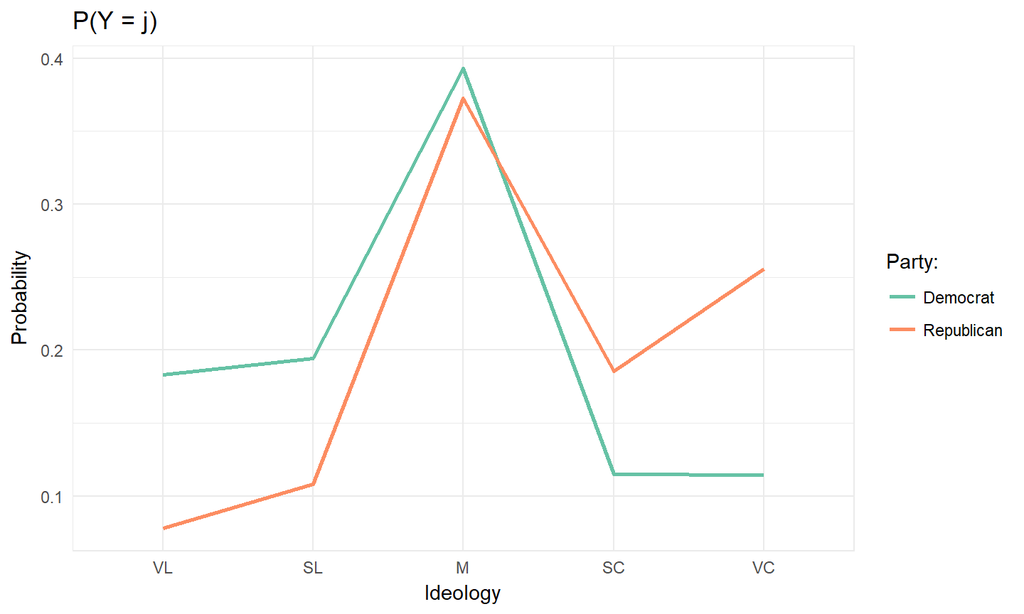

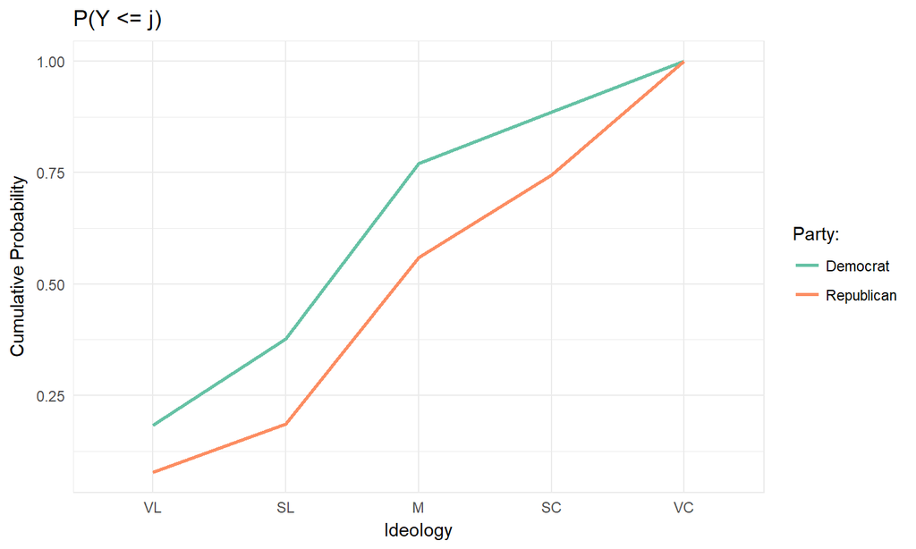

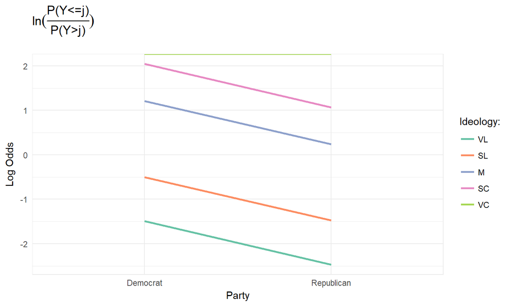

## References

- Agresti, A. (2007). An Introduction to Categorical Data Analysis. Hoboken, NJ: Wiley-Interscience.
- 8.4 - The Proportional-Odds Cumulative Logit Model. (n.d.). Retrieved November 07, 2017, from https://onlinecourses.science.psu.edu/stat504/node/176